# Advanced Quarto Features - Live Demo

Author

Dr. Gretchen LeBuhn & Dr. Nicole Adelstein

Published

## Introduction

This document demonstrates professional Quarto features including:

- Labeled figures with cross-references
- Formatted tables with captions
- Mathematical equations
- Callout blocks
- Multiple layout options

We’ll analyze bee species richness data from three study sites.

## Load Libraries and Data

```r
library(tidyverse)
library(knitr)

# Read bee data from CSV
bee_data <- read.csv("bee_data.csv")

# View first few rows
head(bee_data)
```

```
     site richness latitude temperature
1   North       15     38.5          22
2   North       14     38.5          24
3   North       16     38.5          23
4   North       13     38.5          25
5 Central       12     38.0          25
6 Central       13     38.0          26
```

## Professional Figures

### Species Richness by Site

Let’s visualize species richness across our three study sites.

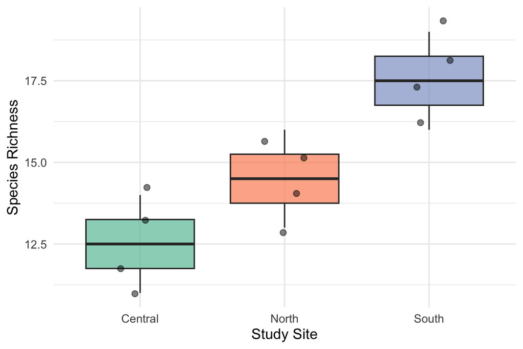

Figure 1: Species richness varies significantly among sites, with the southern site showing highest diversity.

```r
ggplot(bee_data, aes(x = site, y = richness, fill = site)) +
  geom_boxplot(alpha = 0.7) +
  geom_jitter(width = 0.2, alpha = 0.5, size = 2) +
  labs(x = "Study Site",
       y = "Species Richness") +
  theme_minimal(base_size = 12) +
  theme(legend.position = "none") +
  scale_fill_brewer(palette = "Set2")
```

As shown in Figure 1, the southern site consistently shows higher species richness compared to northern and central sites. This pattern may be related to temperature gradients across sites.

### Temperature Patterns

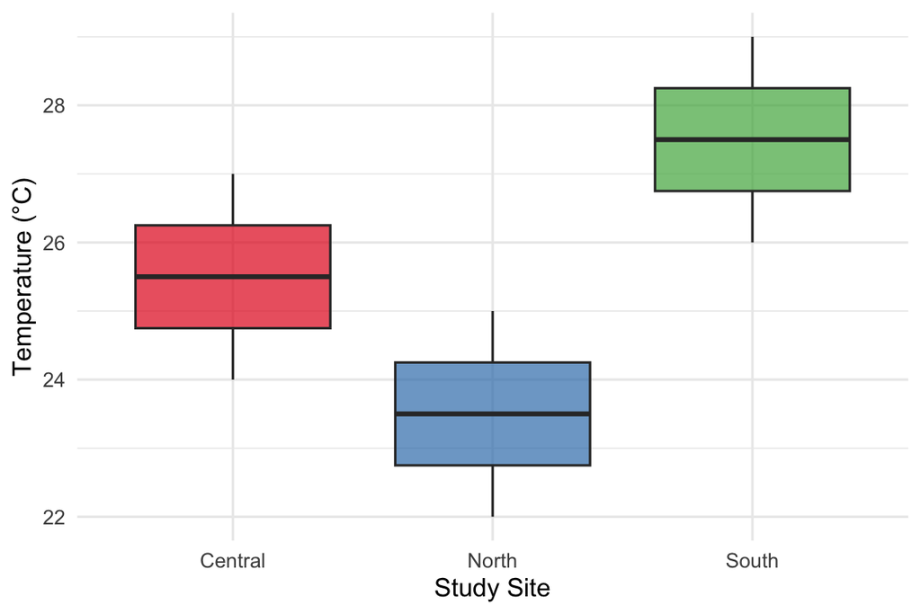

Figure 2: Mean temperature increases from north to south across study sites.

```r
ggplot(bee_data, aes(x = site, y = temperature, fill = site)) +
  geom_boxplot(alpha = 0.7) +
  labs(x = "Study Site",
       y = "Temperature (°C)") +
  theme_minimal(base_size = 12) +
  theme(legend.position = "none") +
  scale_fill_brewer(palette = "Set1")
```

**NoteSampling Period**

All measurements were taken during peak flowering season (June-August 2024) to standardize environmental conditions.

### Multiple Plots Side-by-Side

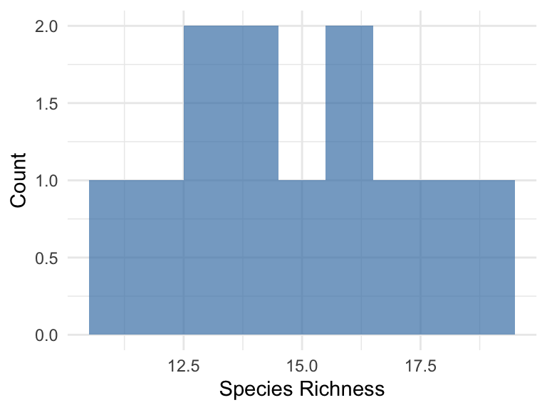

(a) Species richness distribution

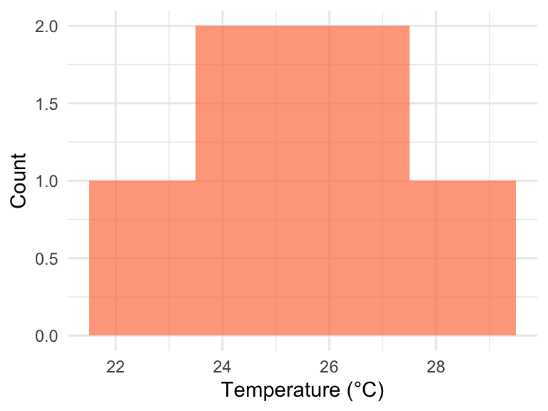

(b) Temperature distribution

Figure 3: Comparison of richness and temperature patterns across sites.

```r
# Plot 1: Richness
ggplot(bee_data, aes(x = richness)) +
  geom_histogram(binwidth = 1, fill = "steelblue", alpha = 0.7) +
  labs(x = "Species Richness", y = "Count") +
  theme_minimal()

# Plot 2: Temperature
ggplot(bee_data, aes(x = temperature)) +
  geom_histogram(binwidth = 1, fill = "coral", alpha = 0.7) +
  labs(x = "Temperature (°C)", y = "Count") +
  theme_minimal()
```

## Professional Tables

### Summary Statistics

Now let’s create a professional summary table of our data.

```r
# Calculate summary statistics
summary_stats <- bee_data %>%
  group_by(site) %>%
  summarise(
    `Mean Richness` = round(mean(richness), 1),
    `SD Richness` = round(sd(richness), 1),
    `Mean Temp (°C)` = round(mean(temperature), 1),
    `SD Temp` = round(sd(temperature), 1),
    N = n()
  )

# Create formatted table
kable(summary_stats,
      digits = 1,
      align = c('l', 'c', 'c', 'c', 'c', 'c'))
```

Table 1: Summary statistics of species richness and temperature by study site.

| site | Mean Richness | SD Richness | Mean Temp (°C) | SD Temp | N |
| --- | --- | --- | --- | --- | --- |
| Central | 12.5 | 1.3 | 25.5 | 1.3 | 4 |
| North | 14.5 | 1.3 | 23.5 | 1.3 | 4 |
| South | 17.5 | 1.3 | 27.5 | 1.3 | 4 |

Statistical analysis (Table 1) reveals that the southern site has the highest mean species richness (17.5 species) and warmest temperatures.

### ANOVA Results

```r
# Run ANOVA
anova_results <- aov(richness ~ site, data = bee_data)
anova_summary <- summary(anova_results)

# Extract values
anova_df <- as.data.frame(anova_summary[[1]])

# Format for display
anova_table <- data.frame(
  Source = row.names(anova_df),
  Df = anova_df$Df,
  `Sum Sq` = round(anova_df$`Sum Sq`, 2),
  `Mean Sq` = round(anova_df$`Mean Sq`, 2),
  `F value` = round(anova_df$`F value`, 2),
  `P value` = ifelse(anova_df$`Pr(>F)` < 0.001, "< 0.001",
                     round(anova_df$`Pr(>F)`, 3)),
  check.names = FALSE
)

kable(anova_table, row.names = FALSE)
```

Table 2: ANOVA results testing differences in species richness among sites.

| Source | Df | Sum Sq | Mean Sq | F value | P value |
| --- | --- | --- | --- | --- | --- |
| site | 2 | 50.67 | 25.33 | 15.2 | 0.001 |
| Residuals | 9 | 15.00 | 1.67 | NA | NA |

Results from Table 2 indicate highly significant differences in species richness among the three study sites.

## Mathematical Equations

### Shannon Diversity Index

We calculated Shannon diversity using the formula:

$$H' = -\sum_{i=1}^{S} p_i \ln(p_i)
\tag{1}$$

where $S$ is the total number of species and $p_i$ is the proportion of individuals belonging to species $i$.

The Shannon diversity index (Equation 1) provides a measure that accounts for both species richness and evenness in the community.

### Simpson’s Index

An alternative diversity metric is Simpson’s index:

$$D = 1 - \sum_{i=1}^{S} p_i^2
\tag{2}$$

Both Equation 1 and Equation 2 are commonly used in community ecology, with Simpson’s index being less sensitive to rare species.

## Relationship Between Temperature and Richness

Let’s explore whether temperature predicts species richness.

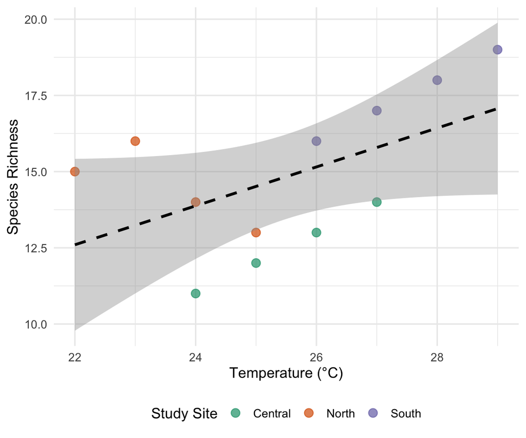

Figure 4: Positive relationship between temperature and species richness across all sites.

```r
ggplot(bee_data, aes(x = temperature, y = richness, color = site)) +
  geom_point(size = 3, alpha = 0.7) +
  geom_smooth(method = "lm", se = TRUE, color = "black", linetype = "dashed") +
  labs(x = "Temperature (°C)",
       y = "Species Richness",
       color = "Study Site") +
  theme_minimal(base_size = 12) +
  theme(legend.position = "bottom") +
  scale_color_brewer(palette = "Dark2")
```

**TipAnalysis Suggestion**

The positive trend in Figure 4 suggests temperature may be an important driver of bee diversity. Consider including additional environmental variables (humidity, floral resources) in future analyses to better understand this pattern.

## Column Layout Example

### Next Steps

- Expand sampling to additional sites
- Include rarefaction analysis
- Measure floral resource availability
- Conduct seasonal comparison

## Conclusions

This analysis demonstrates several important patterns:

1. Species richness varies significantly among study sites (Figure 1, Table 2)
2. The southern site shows consistently higher diversity (Table 1)
3. Temperature appears to be positively correlated with richness (Figure 4)
4. These patterns warrant further investigation with expanded sampling

**ImportantKey Takeaway**

Geographic gradients in bee diversity may be driven by temperature, but additional environmental factors should be considered before drawing causal conclusions.

**Document rendered:** February 11, 2026